# Optimal Treatment Analysis

## Outcome Variable

**Outcome Variable:** whz

## Predictor Variables

**Intervention Variable:** vagbrth

**Adjustment Set:**

- arm
- sex
- W_mage
- meducyrs
- feducyrs
- W_mhtcm
- W_mwtkg
- W_mbmi
- single
- brthmon
- W_parity
- delta_W_mage
- delta_meducyrs
- delta_feducyrs
- delta_W_mhtcm
- delta_W_mwtkg
- delta_W_mbmi
- delta_single
- delta_brthmon
- delta_W_parity

## Stratifying Variables

The analysis was stratified on these variable(s):

- agecat
- studyid
- country

## Data Summary

| agecat | studyid | country | vagbrth | n_cell | n |
| --- | --- | --- | --- | --- | --- |
| Birth | ki1000108-CMC-V-BCS-2002 | INDIA | 0 | 10 | 88 |
| Birth | ki1000108-CMC-V-BCS-2002 | INDIA | 1 | 78 | 88 |
| Birth | ki1000108-IRC | INDIA | 0 | 66 | 343 |
| Birth | ki1000108-IRC | INDIA | 1 | 277 | 343 |
| Birth | ki1017093c-NIH-Crypto | BANGLADESH | 0 | 1 | 17 |
| Birth | ki1017093c-NIH-Crypto | BANGLADESH | 1 | 16 | 17 |
| Birth | ki1119695-PROBIT | BELARUS | 0 | 713 | 6739 |
| Birth | ki1119695-PROBIT | BELARUS | 1 | 6026 | 6739 |
| Birth | ki1126311-ZVITAMBO | ZIMBABWE | 0 | 1099 | 12813 |
| Birth | ki1126311-ZVITAMBO | ZIMBABWE | 1 | 11714 | 12813 |
| Birth | kiGH5241-JiVitA-3 | BANGLADESH | 0 | 0 | 7676 |
| Birth | kiGH5241-JiVitA-3 | BANGLADESH | 1 | 7676 | 7676 |
| Birth | kiGH5241-JiVitA-4 | BANGLADESH | 0 | 0 | 185 |
| Birth | kiGH5241-JiVitA-4 | BANGLADESH | 1 | 185 | 185 |
| 6 months | ki1000108-CMC-V-BCS-2002 | INDIA | 0 | 25 | 368 |
| 6 months | ki1000108-CMC-V-BCS-2002 | INDIA | 1 | 343 | 368 |
| 6 months | ki1000108-IRC | INDIA | 0 | 68 | 408 |
| 6 months | ki1000108-IRC | INDIA | 1 | 340 | 408 |
| 6 months | ki1017093b-PROVIDE | BANGLADESH | 0 | 134 | 582 |
| 6 months | ki1017093b-PROVIDE | BANGLADESH | 1 | 448 | 582 |
| 6 months | ki1017093c-NIH-Crypto | BANGLADESH | 0 | 187 | 457 |
| 6 months | ki1017093c-NIH-Crypto | BANGLADESH | 1 | 270 | 457 |
| 6 months | ki1066203-TanzaniaChild2 | TANZANIA, UNITED REPUBLIC OF | 0 | 189 | 2004 |
| 6 months | ki1066203-TanzaniaChild2 | TANZANIA, UNITED REPUBLIC OF | 1 | 1815 | 2004 |
| 6 months | ki1119695-PROBIT | BELARUS | 0 | 811 | 7664 |
| 6 months | ki1119695-PROBIT | BELARUS | 1 | 6853 | 7664 |
| 6 months | ki1126311-ZVITAMBO | ZIMBABWE | 0 | 706 | 8197 |
| 6 months | ki1126311-ZVITAMBO | ZIMBABWE | 1 | 7491 | 8197 |
| 6 months | kiGH5241-JiVitA-3 | BANGLADESH | 0 | 526 | 8273 |
| 6 months | kiGH5241-JiVitA-3 | BANGLADESH | 1 | 7747 | 8273 |
| 6 months | kiGH5241-JiVitA-4 | BANGLADESH | 0 | 72 | 1054 |
| 6 months | kiGH5241-JiVitA-4 | BANGLADESH | 1 | 982 | 1054 |
| 24 months | ki1000108-CMC-V-BCS-2002 | INDIA | 0 | 25 | 372 |
| 24 months | ki1000108-CMC-V-BCS-2002 | INDIA | 1 | 347 | 372 |
| 24 months | ki1000108-IRC | INDIA | 0 | 69 | 409 |
| 24 months | ki1000108-IRC | INDIA | 1 | 340 | 409 |
| 24 months | ki1017093b-PROVIDE | BANGLADESH | 0 | 137 | 578 |
| 24 months | ki1017093b-PROVIDE | BANGLADESH | 1 | 441 | 578 |
| 24 months | ki1017093c-NIH-Crypto | BANGLADESH | 0 | 99 | 260 |
| 24 months | ki1017093c-NIH-Crypto | BANGLADESH | 1 | 161 | 260 |
| 24 months | ki1066203-TanzaniaChild2 | TANZANIA, UNITED REPUBLIC OF | 0 | 2 | 6 |
| 24 months | ki1066203-TanzaniaChild2 | TANZANIA, UNITED REPUBLIC OF | 1 | 4 | 6 |
| 24 months | ki1119695-PROBIT | BELARUS | 0 | 150 | 1589 |
| 24 months | ki1119695-PROBIT | BELARUS | 1 | 1439 | 1589 |
| 24 months | ki1126311-ZVITAMBO | ZIMBABWE | 0 | 28 | 417 |
| 24 months | ki1126311-ZVITAMBO | ZIMBABWE | 1 | 389 | 417 |
| 24 months | kiGH5241-JiVitA-3 | BANGLADESH | 0 | 224 | 4257 |
| 24 months | kiGH5241-JiVitA-3 | BANGLADESH | 1 | 4033 | 4257 |
| 24 months | kiGH5241-JiVitA-4 | BANGLADESH | 0 | 69 | 1061 |
| 24 months | kiGH5241-JiVitA-4 | BANGLADESH | 1 | 992 | 1061 |

The following strata were considered:

- agecat: 24 months, studyid: ki1000108-CMC-V-BCS-2002, country: INDIA
- agecat: 24 months, studyid: ki1000108-IRC, country: INDIA
- agecat: 24 months, studyid: ki1017093b-PROVIDE, country: BANGLADESH
- agecat: 24 months, studyid: ki1017093c-NIH-Crypto, country: BANGLADESH
- agecat: 24 months, studyid: ki1066203-TanzaniaChild2, country: TANZANIA, UNITED REPUBLIC OF
- agecat: 24 months, studyid: ki1119695-PROBIT, country: BELARUS
- agecat: 24 months, studyid: ki1126311-ZVITAMBO, country: ZIMBABWE
- agecat: 24 months, studyid: kiGH5241-JiVitA-3, country: BANGLADESH
- agecat: 24 months, studyid: kiGH5241-JiVitA-4, country: BANGLADESH
- agecat: 6 months, studyid: ki1000108-CMC-V-BCS-2002, country: INDIA
- agecat: 6 months, studyid: ki1000108-IRC, country: INDIA
- agecat: 6 months, studyid: ki1017093b-PROVIDE, country: BANGLADESH
- agecat: 6 months, studyid: ki1017093c-NIH-Crypto, country: BANGLADESH
- agecat: 6 months, studyid: ki1066203-TanzaniaChild2, country: TANZANIA, UNITED REPUBLIC OF
- agecat: 6 months, studyid: ki1119695-PROBIT, country: BELARUS
- agecat: 6 months, studyid: ki1126311-ZVITAMBO, country: ZIMBABWE
- agecat: 6 months, studyid: kiGH5241-JiVitA-3, country: BANGLADESH
- agecat: 6 months, studyid: kiGH5241-JiVitA-4, country: BANGLADESH
- agecat: Birth, studyid: ki1000108-CMC-V-BCS-2002, country: INDIA
- agecat: Birth, studyid: ki1000108-IRC, country: INDIA
- agecat: Birth, studyid: ki1017093c-NIH-Crypto, country: BANGLADESH
- agecat: Birth, studyid: ki1119695-PROBIT, country: BELARUS
- agecat: Birth, studyid: ki1126311-ZVITAMBO, country: ZIMBABWE
- agecat: Birth, studyid: kiGH5241-JiVitA-3, country: BANGLADESH
- agecat: Birth, studyid: kiGH5241-JiVitA-4, country: BANGLADESH

### Dropped Strata

Some strata were dropped due to rare outcomes:

- agecat: Birth, studyid: ki1017093c-NIH-Crypto, country: BANGLADESH
- agecat: Birth, studyid: kiGH5241-JiVitA-3, country: BANGLADESH
- agecat: Birth, studyid: kiGH5241-JiVitA-4, country: BANGLADESH
- agecat: 24 months, studyid: ki1066203-TanzaniaChild2, country: TANZANIA, UNITED REPUBLIC OF

## Methods Detail

We’re interested in the causal parameters $E[Y_a]$ for all values of $a \in \mathcal{A}$. These parameters represent the mean outcome if, possibly contrary to fact, we intervened to set all units to have $A=a$. Under the randomization and positivity assumptions, these are identified by the statistical parameters $\psi_a=E_W[E_{Y|A,W}(Y|A=a,W)]$. In addition, we’re interested in the mean of $Y$, $E[Y]$ under no intervention (the observed mean). We will estimate these parameters by using SuperLearner to fit the relevant likelihood factors – $E_{Y|A,W}(Y|A=a,W)$ and $p(A=a|W)$, and then updating our likelihood fit using a joint TMLE.

For unadjusted analyses ($W=\{\}$), initial likelihoods were estimated using Lrnr_glm to estimate the simple $E(Y|A)$ and Lrnr_mean to estimate $p(A)$. For adjusted analyses, a small library containing Lrnr_glmnet, Lrnr_xgboost, and Lrnr_mean was used.

Having estimated these parameters, we will then use the delta method to estimate relative risks and attributable risks relative to a prespecified baseline level of $A$.

# Results Detail

## Results Plots

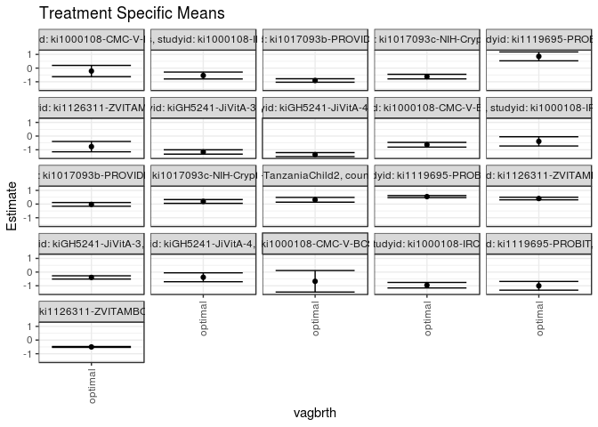

## Results Table

### Parameter: TSM

| agecat | studyid | country | intervention_level | baseline_level | estimate | ci_lower | ci_upper |
| --- | --- | --- | --- | --- | --- | --- | --- |
| Birth | ki1000108-CMC-V-BCS-2002 | INDIA | optimal | observed | -0.6750475 | -1.4623318 | 0.1122367 |
| Birth | ki1000108-IRC | INDIA | optimal | observed | -0.9605162 | -1.1616052 | -0.7594273 |
| Birth | ki1119695-PROBIT | BELARUS | optimal | observed | -1.0035822 | -1.3230824 | -0.6840821 |
| Birth | ki1126311-ZVITAMBO | ZIMBABWE | optimal | observed | -0.5024596 | -0.5343929 | -0.4705264 |
| 6 months | ki1000108-CMC-V-BCS-2002 | INDIA | optimal | observed | -0.6326910 | -0.8048272 | -0.4605547 |
| 6 months | ki1000108-IRC | INDIA | optimal | observed | -0.3861694 | -0.7236981 | -0.0486407 |
| 6 months | ki1017093b-PROVIDE | BANGLADESH | optimal | observed | -0.0223436 | -0.1590951 | 0.1144080 |
| 6 months | ki1017093c-NIH-Crypto | BANGLADESH | optimal | observed | 0.1911593 | 0.0524882 | 0.3298305 |
| 6 months | ki1066203-TanzaniaChild2 | TANZANIA, UNITED REPUBLIC OF | optimal | observed | 0.3137445 | 0.1396791 | 0.4878098 |
| 6 months | ki1119695-PROBIT | BELARUS | optimal | observed | 0.5455589 | 0.4706593 | 0.6204586 |
| 6 months | ki1126311-ZVITAMBO | ZIMBABWE | optimal | observed | 0.4072969 | 0.3117110 | 0.5028828 |
| 6 months | kiGH5241-JiVitA-3 | BANGLADESH | optimal | observed | -0.3910252 | -0.5107498 | -0.2713007 |
| 6 months | kiGH5241-JiVitA-4 | BANGLADESH | optimal | observed | -0.3814372 | -0.7068926 | -0.0559819 |
| 24 months | ki1000108-CMC-V-BCS-2002 | INDIA | optimal | observed | -0.2163470 | -0.6281382 | 0.1954441 |
| 24 months | ki1000108-IRC | INDIA | optimal | observed | -0.5443128 | -0.7957606 | -0.2928649 |
| 24 months | ki1017093b-PROVIDE | BANGLADESH | optimal | observed | -0.9073294 | -1.0343764 | -0.7802823 |
| 24 months | ki1017093c-NIH-Crypto | BANGLADESH | optimal | observed | -0.6228275 | -0.7912936 | -0.4543613 |
| 24 months | ki1119695-PROBIT | BELARUS | optimal | observed | 0.8573883 | 0.5319736 | 1.1828030 |
| 24 months | ki1126311-ZVITAMBO | ZIMBABWE | optimal | observed | -0.7704480 | -1.1472107 | -0.3936853 |
| 24 months | kiGH5241-JiVitA-3 | BANGLADESH | optimal | observed | -1.1615418 | -1.3197393 | -1.0033443 |
| 24 months | kiGH5241-JiVitA-4 | BANGLADESH | optimal | observed | -1.3561132 | -1.5044522 | -1.2077743 |

### Parameter: E(Y)

| agecat | studyid | country | intervention_level | baseline_level | estimate | ci_lower | ci_upper |
| --- | --- | --- | --- | --- | --- | --- | --- |
| Birth | ki1000108-CMC-V-BCS-2002 | INDIA | observed | observed | -0.6275000 | -0.9746292 | -0.2803708 |
| Birth | ki1000108-IRC | INDIA | observed | observed | -1.0105831 | -1.1973019 | -0.8238643 |
| Birth | ki1119695-PROBIT | BELARUS | observed | observed | -1.1877267 | -1.5203042 | -0.8551491 |
| Birth | ki1126311-ZVITAMBO | ZIMBABWE | observed | observed | -0.5165387 | -0.5425056 | -0.4905717 |
| 6 months | ki1000108-CMC-V-BCS-2002 | INDIA | observed | observed | -0.5026766 | -0.6536848 | -0.3516685 |
| 6 months | ki1000108-IRC | INDIA | observed | observed | -0.5989297 | -0.7344491 | -0.4634104 |
| 6 months | ki1017093b-PROVIDE | BANGLADESH | observed | observed | -0.2083706 | -0.2927992 | -0.1239419 |
| 6 months | ki1017093c-NIH-Crypto | BANGLADESH | observed | observed | 0.0515536 | -0.0469240 | 0.1500313 |
| 6 months | ki1066203-TanzaniaChild2 | TANZANIA, UNITED REPUBLIC OF | observed | observed | 0.0769382 | 0.0241090 | 0.1297674 |
| 6 months | ki1119695-PROBIT | BELARUS | observed | observed | 0.5810067 | 0.5014871 | 0.6605262 |
| 6 months | ki1126311-ZVITAMBO | ZIMBABWE | observed | observed | 0.3058247 | 0.2796439 | 0.3320055 |
| 6 months | kiGH5241-JiVitA-3 | BANGLADESH | observed | observed | -0.5895117 | -0.6169445 | -0.5620788 |
| 6 months | kiGH5241-JiVitA-4 | BANGLADESH | observed | observed | -0.3513899 | -0.4292990 | -0.2734809 |
| 24 months | ki1000108-CMC-V-BCS-2002 | INDIA | observed | observed | -0.5571505 | -0.6585247 | -0.4557763 |
| 24 months | ki1000108-IRC | INDIA | observed | observed | -0.7458150 | -0.8368180 | -0.6548120 |
| 24 months | ki1017093b-PROVIDE | BANGLADESH | observed | observed | -0.8879412 | -0.9708680 | -0.8050144 |
| 24 months | ki1017093c-NIH-Crypto | BANGLADESH | observed | observed | -0.8343077 | -0.9482310 | -0.7203844 |
| 24 months | ki1119695-PROBIT | BELARUS | observed | observed | 0.8061601 | 0.6592496 | 0.9530705 |
| 24 months | ki1126311-ZVITAMBO | ZIMBABWE | observed | observed | -1.1870743 | -1.2881393 | -1.0860094 |
| 24 months | kiGH5241-JiVitA-3 | BANGLADESH | observed | observed | -1.2932441 | -1.3257311 | -1.2607570 |
| 24 months | kiGH5241-JiVitA-4 | BANGLADESH | observed | observed | -1.2404241 | -1.3064768 | -1.1743715 |

### Parameter: PAR

| agecat | studyid | country | intervention_level | baseline_level | estimate | ci_lower | ci_upper |
| --- | --- | --- | --- | --- | --- | --- | --- |
| Birth | ki1000108-CMC-V-BCS-2002 | INDIA | optimal | observed | 0.0475475 | -0.6935648 | 0.7886598 |
| Birth | ki1000108-IRC | INDIA | optimal | observed | -0.0500668 | -0.1508499 | 0.0507162 |
| Birth | ki1119695-PROBIT | BELARUS | optimal | observed | -0.1841444 | -0.3363805 | -0.0319084 |
| Birth | ki1126311-ZVITAMBO | ZIMBABWE | optimal | observed | -0.0140790 | -0.0317149 | 0.0035568 |
| 6 months | ki1000108-CMC-V-BCS-2002 | INDIA | optimal | observed | 0.1300143 | 0.0360350 | 0.2239937 |
| 6 months | ki1000108-IRC | INDIA | optimal | observed | -0.2127603 | -0.5239403 | 0.0984196 |
| 6 months | ki1017093b-PROVIDE | BANGLADESH | optimal | observed | -0.1860270 | -0.3110764 | -0.0609776 |
| 6 months | ki1017093c-NIH-Crypto | BANGLADESH | optimal | observed | -0.1396057 | -0.2372831 | -0.0419284 |
| 6 months | ki1066203-TanzaniaChild2 | TANZANIA, UNITED REPUBLIC OF | optimal | observed | -0.2368063 | -0.4027042 | -0.0709084 |
| 6 months | ki1119695-PROBIT | BELARUS | optimal | observed | 0.0354477 | -0.0136648 | 0.0845603 |
| 6 months | ki1126311-ZVITAMBO | ZIMBABWE | optimal | observed | -0.1014722 | -0.1929124 | -0.0100321 |
| 6 months | kiGH5241-JiVitA-3 | BANGLADESH | optimal | observed | -0.1984864 | -0.3128956 | -0.0840773 |
| 6 months | kiGH5241-JiVitA-4 | BANGLADESH | optimal | observed | 0.0300473 | -0.2812036 | 0.3412982 |
| 24 months | ki1000108-CMC-V-BCS-2002 | INDIA | optimal | observed | -0.3408035 | -0.7387738 | 0.0571668 |
| 24 months | ki1000108-IRC | INDIA | optimal | observed | -0.2015022 | -0.4264783 | 0.0234739 |
| 24 months | ki1017093b-PROVIDE | BANGLADESH | optimal | observed | 0.0193882 | -0.0876717 | 0.1264480 |
| 24 months | ki1017093c-NIH-Crypto | BANGLADESH | optimal | observed | -0.2114802 | -0.3454660 | -0.0774945 |
| 24 months | ki1119695-PROBIT | BELARUS | optimal | observed | -0.0512283 | -0.2685151 | 0.1660585 |
| 24 months | ki1126311-ZVITAMBO | ZIMBABWE | optimal | observed | -0.4166263 | -0.7837282 | -0.0495245 |
| 24 months | kiGH5241-JiVitA-3 | BANGLADESH | optimal | observed | -0.1317023 | -0.2857877 | 0.0223832 |
| 24 months | kiGH5241-JiVitA-4 | BANGLADESH | optimal | observed | 0.1156891 | -0.0169275 | 0.2483057 |